# Tugas Kelompok MPDW Pertemuan 8

G1401211001 Karimatu Ain  
G1401211022 Much.Fazrin Sepranjani Fatah  
G1401211073 Kamilah Nurul Azizah  
G1401211087 Pingkan Febbe Fiorela Kereh  
G1401211106 Megawati Roito Panjaitan

## Packages dan Data

### Library

```r
library(ggplot2)
library(tsibble)
library(tseries)
library(MASS)
library(dplyr)
library(TTR)
library(forecast)
library(lmtest)
library(orcutt)
library(HoRM)
library(dLagM)
library(dynlm)
library(MLmetrics)
library(car)
library(TSA)
library(aTSA)
```

### Import Data

Data yang digunakan merupakan data harga bawang merah (rupiah/kg) di kota Surabaya perminggu (Januari 2018 - Agustus 2023) yang bersumber dari bi.go.id

```r
library(rio)
data <- import("https://raw.githubusercontent.com/kamilahnrl/mpdw/main/Kelompok%203/data.xlsx")
str(data)
```

```
## 'data.frame':    295 obs. of  2 variables:
##  $ No         : num  1 2 3 4 5 6 7 8 9 10 ...
##  $ BawangMerah: num  19300 18300 18000 18350 18500 ...
```

## Eksplorasi Data

### Plot Data Penuh

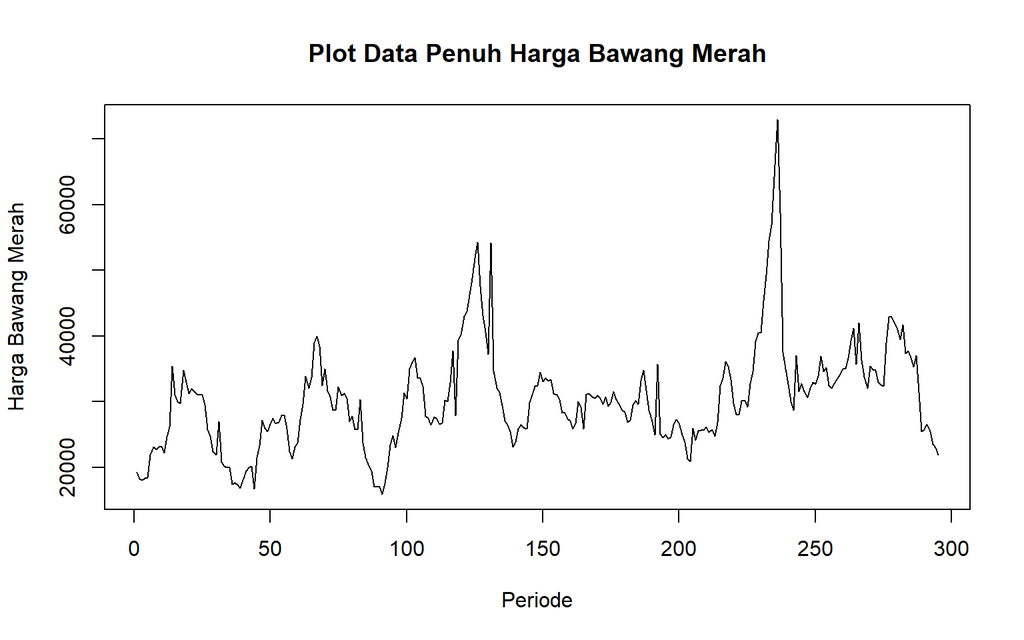

```r
data.ts <- ts(data$BawangMerah)
plot.ts(data.ts, lty=1, xlab="Periode", ylab="Harga Bawang Merah", main="Plot Data Penuh Harga Bawang Merah")
```

Plot deret waktu di atas menunjukkan bahwa data stasioner dalam rataan, ditandai dengan data cenderung menyebar di sekitar nilai tengahnya

### Plot Data Latih

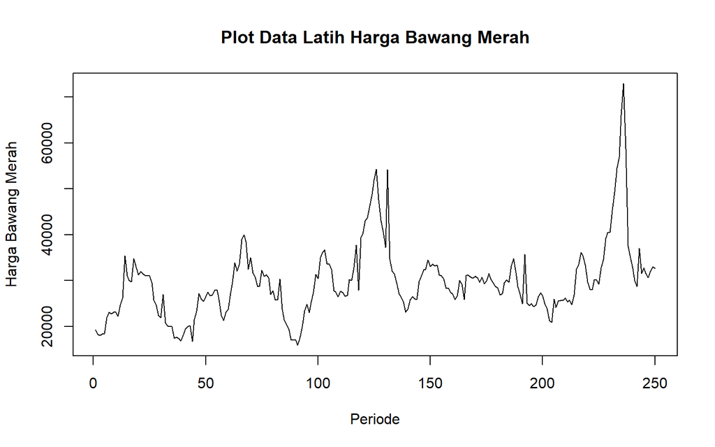

```r
train <- data$BawangMerah[1:250]
train.ts <- ts(train)
plot.ts(train.ts, lty=1, xlab="Periode", ylab="Harga Bawang Merah", main="Plot Data Latih Harga Bawang Merah")
```

Berdasarkan plot data deret waktu pada data latih, terlihat bahwa data stasioner dalam rataan, ditandai dengan data cenderung menyebar di sekitar nilai tengahnya

#### Plot Data Uji

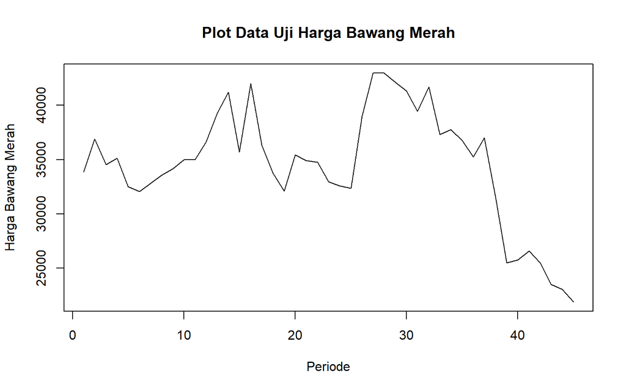

```r
test <- data$BawangMerah[-c(1:250)]
test.ts<-ts(test)
plot.ts(test.ts, lty=1, xlab="Periode", ylab="Harga Bawang Merah", main="Plot Data Uji Harga Bawang Merah")
```

## Uji Stasioneritas Data

### Plot ACF

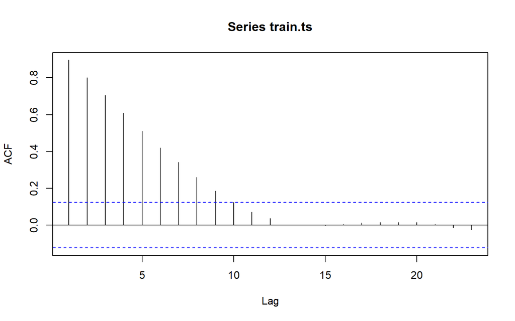

```r
acf(train.ts)
```

Berdasarkan plot ACF, terlihat bahwa plot ACF pada data tersebut *tails off slowly* atau menurun secara perlahan.

### Uji ADF

```r
tseries::adf.test(train.ts)
```

```
##
##  Augmented Dickey-Fuller Test
##
## data:  train.ts
## Dickey-Fuller = -4.1727, Lag order = 6, p-value = 0.01
## alternative hypothesis: stationary
```

$H_0$ : Data tidak stasioner dalam rataan

$H_1$ : Data stasioner dalam rataan

Berdasarkan uji ADF tersebut, didapat *p-value* sebesar 0.01 yang lebih kecil dari taraf nyata 5% sehingga tolak $H_0$ dan menandakan bahwa data stasioner dalam rataan.

### Plot Box-Cox

```r
index <- seq(1:250)
bc = boxcox(train.ts~index, lambda = seq(-2,4,by=0.01))
```

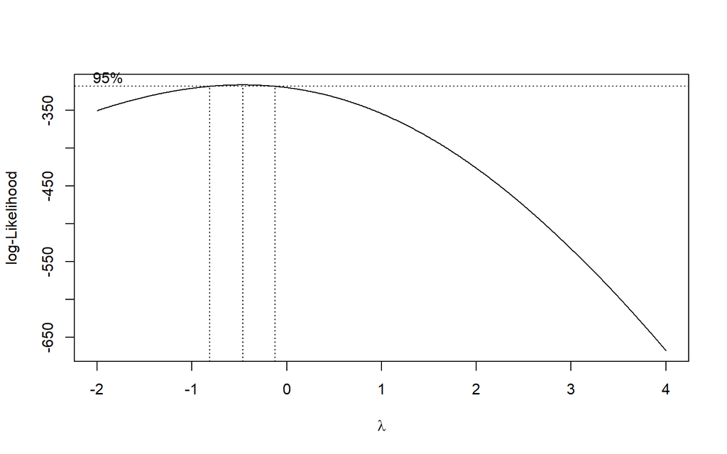

```r
#Nilai Rounded Lambda
lambda <- bc$x[which.max(bc$y)]
lambda
```

```
## [1] -0.46
```

```r
#SK
bc$x[bc$y > max(bc$y) - 1/2 * qchisq(.95,1)]
```

```
##  [1] -0.81 -0.80 -0.79 -0.78 -0.77 -0.76 -0.75 -0.74 -0.73 -0.72 -0.71 -0.70
## [13] -0.69 -0.68 -0.67 -0.66 -0.65 -0.64 -0.63 -0.62 -0.61 -0.60 -0.59 -0.58
## [25] -0.57 -0.56 -0.55 -0.54 -0.53 -0.52 -0.51 -0.50 -0.49 -0.48 -0.47 -0.46
## [37] -0.45 -0.44 -0.43 -0.42 -0.41 -0.40 -0.39 -0.38 -0.37 -0.36 -0.35 -0.34
## [49] -0.33 -0.32 -0.31 -0.30 -0.29 -0.28 -0.27 -0.26 -0.25 -0.24 -0.23 -0.22
## [61] -0.21 -0.20 -0.19 -0.18 -0.17 -0.16 -0.15 -0.14 -0.13
```

Gambar di atas menunjukkan nilai *rounded value* ($\lambda$) optimum sebesar **= -0.46** dan pada selang kepercayaan 95% nilai memiliki batas bawah **-0.81* dan batas atas** -0.13**. Selang tersebut tidak memuat nilai 1 sehingga dapat dikatakan bahwa data tidak stasioner dalam ragam.

Dengan demikian, data stasioner dalam rataan tetapi tidak stasioner dalam ragam.

### Penanganan Ketidakstasioneran dalam Ragam (Tranformasi BoxCox)

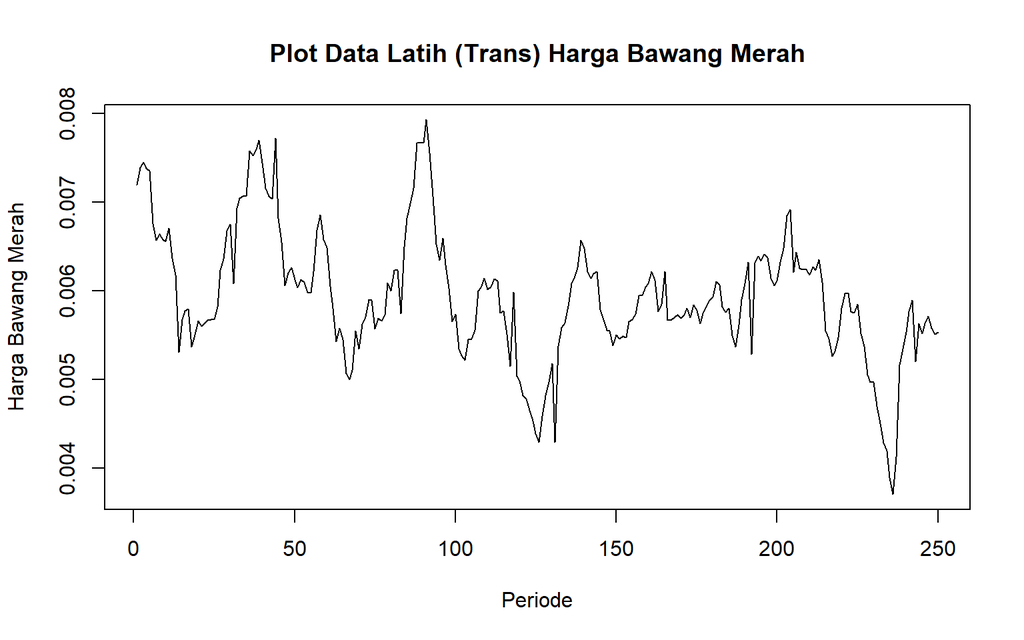

```r
train.trans <- (train.ts)^(-0.5)
plot.ts(train.trans, lty=1, xlab="Periode", ylab="Harga Bawang Merah", main="Plot Data Latih (Trans) Harga Bawang Merah")
```

### Plot BoxCox Transformasi

```r
index <- seq(1:250)
bc = boxcox(train.trans~index, lambda = seq(-4,10,by=0.1))
```

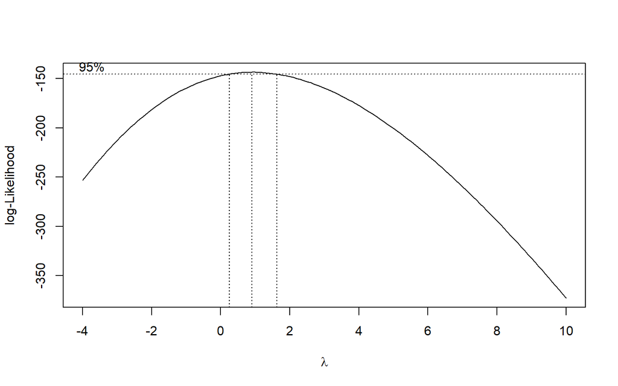

```r
#Nilai Rounded Lambda
lambda <- bc$x[which.max(bc$y)]
lambda
```

```
## [1] 0.9
```

```r
#SK
bc$x[bc$y > max(bc$y) - 1/2 * qchisq(.95,1)]
```

```
##  [1] 0.3 0.4 0.5 0.6 0.7 0.8 0.9 1.0 1.1 1.2 1.3 1.4 1.5 1.6
```

SK sudah memuat nilai satu, maka stationer dalam ragam sudah tertangani.

## Identifikasi Model

### Plot ACF

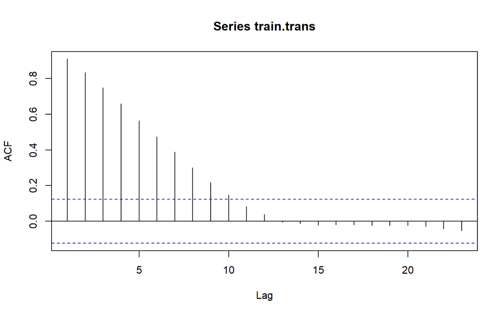

```r
acf(train.trans)
```

Berdasarkan plot tersebut, terlihat bahwa plot ACF *tails off*.

### Plot PACF

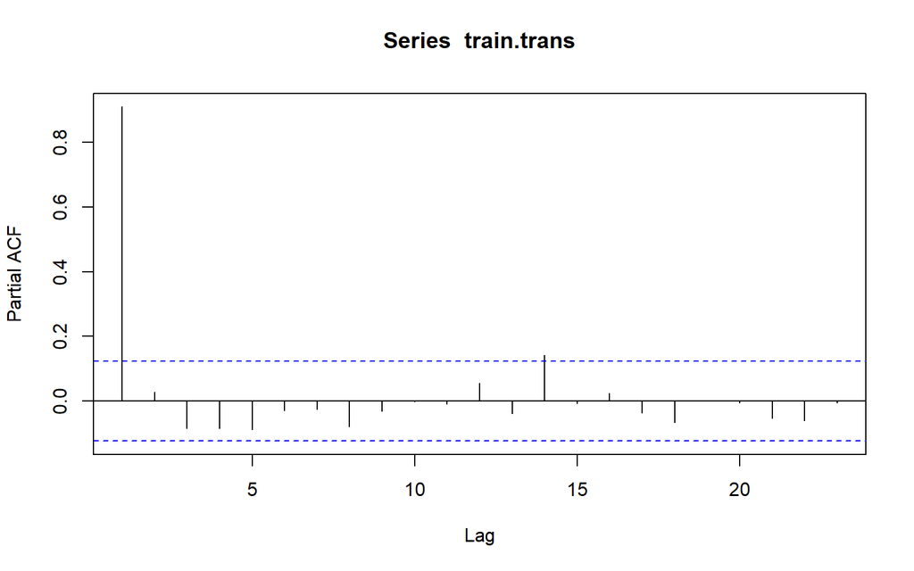

```r
pacf(train.trans)
```

Berdasarkan plot tersebut, terlihat bahwa plot PACF cenderung *cuts off* pada lag ke 1 dan plot ACF menunjukkan *tails off*, maka model tentatifnya adalah ARIMA(1,0,0) atau AR(1).

### Plot EACF

```r
eacf(train.trans)
```

```
## AR/MA
##   0 1 2 3 4 5 6 7 8 9 10 11 12 13
## 0 x x x x x x x x x x o  o  o  o
## 1 o o o o o o o o o o o  o  o  o
## 2 x o o o o o o o o o o  o  x  o
## 3 x o o o o o o o o o o  o  o  o
## 4 x o x o o o o o o o o  o  o  o
## 5 x o x o o o o o o o o  o  o  o
## 6 x o x o o o o o o o o  o  o  o
## 7 x x x o x o o o o o o  o  o  o
```

Identifikasi model menggunakan plot EACF dilakukan dengan melihat ujung segitiga pada pola segitiga nol. Dalam hal ini model tentatif yang terbentuk adalah ARIMA(1,0,0) dan ARIMA (3,0,1)

## Pendugaan Parameter Model Tentatif

### ARIMA(1,0,0)

```r
model1=Arima(train.trans, order=c(1,0,0),method="ML")
summary(model1) #AIC = -3350.89
```

```
## Series: train.trans
## ARIMA(1,0,0) with non-zero mean
##
## Coefficients:
##          ar1   mean
##       0.9185  6e-03
## s.e.  0.0249  2e-04
##
## sigma^2 = 8.635e-08:  log likelihood = 1678.45
## AIC=-3350.89   AICc=-3350.79   BIC=-3340.33
##
## Training set error measures:
##                         ME         RMSE          MAE        MPE     MAPE
## Training set -7.428148e-06 0.0002926797 0.0002078616 -0.3771889 3.584529
##                  MASE        ACF1
## Training set 1.004211 -0.04663677
```

```r
lmtest::coeftest(model1) #seluruh parameter signifikan
```

```
##
## z test of coefficients:
##
##             Estimate Std. Error z value  Pr(>|z|)
## ar1       0.91852410 0.02486823  36.936 < 2.2e-16 ***
## intercept 0.00597903 0.00022687  26.355 < 2.2e-16 ***
## ---
## Signif. codes:  0 '***' 0.001 '**' 0.01 '*' 0.05 '.' 0.1 ' ' 1
```

### ARIMA(3,0,1)

```r
model2=Arima(train.trans, order=c(3,0,1),method="ML")
summary(model2) #AIC = -3352.12
```

```
## Series: train.trans
## ARIMA(3,0,1) with non-zero mean
##
## Coefficients:
##          ar1      ar2      ar3      ma1   mean
##       1.6203  -0.5073  -0.1424  -0.7601  6e-03
## s.e.  0.1405   0.1753   0.0652   0.1306  2e-04
##
## sigma^2 = 8.488e-08:  log likelihood = 1682.06
## AIC=-3352.12   AICc=-3351.78   BIC=-3331
##
## Training set error measures:
##                         ME         RMSE          MAE        MPE     MAPE
## Training set -3.935789e-06 0.0002884156 0.0002052534 -0.3136244 3.534838
##                   MASE         ACF1
## Training set 0.9916104 -0.008725903
```

```r
lmtest::coeftest(model2) #seluruh parameter signifikan
```

```
##
## z test of coefficients:
##
##              Estimate  Std. Error z value  Pr(>|z|)
## ar1        1.62027347  0.14052736 11.5300 < 2.2e-16 ***
## ar2       -0.50725709  0.17534558 -2.8929  0.003817 **
## ar3       -0.14244150  0.06519457 -2.1849  0.028899 *
## ma1       -0.76007517  0.13062448 -5.8188 5.928e-09 ***
## intercept  0.00595797  0.00016033 37.1617 < 2.2e-16 ***
## ---
## Signif. codes:  0 '***' 0.001 '**' 0.01 '*' 0.05 '.' 0.1 ' ' 1
```

Berdasarkan pendugaan parameter di atas, nilai AIC terkecil dimiliki oleh model ARIMA(3,0,1) dan seluruh parameternya signifikan sehingga model yang dipilih adalah model ARIMA(3,0,1).

### Overfitting

Tahapan selanjutnya adalah *overfitting* dilakukan dengan menaikkan orde AR(p) dan MA(q) dari model ARIMA(3,0,1) untuk melihat apakah terdapat model lain yang lebih baik dari model saat ini. Kandidat model *overfitting* adalah ARIMA(4,0,1) dan ARIMA(3,0,2).

```r
# ARIMA(4,0,1)
model3=Arima(train.trans, order=c(4,0,1),method="ML")
summary(model3) #AIC = -3350.62
```

```
## Series: train.trans
## ARIMA(4,0,1) with non-zero mean
##
## Coefficients:
##          ar1      ar2      ar3      ar4      ma1   mean
##       1.5557  -0.4726  -0.0674  -0.0520  -0.7009  6e-03
## s.e.  0.1785   0.1886   0.1234   0.0735   0.1687  2e-04
##
## sigma^2 = 8.506e-08:  log likelihood = 1682.31
## AIC=-3350.62   AICc=-3350.15   BIC=-3325.97
##
## Training set error measures:
##                         ME         RMSE          MAE        MPE    MAPE
## Training set -3.866369e-06 0.0002881221 0.0002048749 -0.3118013 3.52823
##                   MASE         ACF1
## Training set 0.9897818 -0.004616945
```

```r
lmtest::coeftest(model3) #ar3 dan ar4 tidak signifikan
```

```
##
## z test of coefficients:
##
##              Estimate  Std. Error z value  Pr(>|z|)
## ar1        1.55570594  0.17847496  8.7167 < 2.2e-16 ***
## ar2       -0.47264429  0.18858710 -2.5062    0.0122 *
## ar3       -0.06744940  0.12342679 -0.5465    0.5847
## ar4       -0.05201914  0.07353315 -0.7074    0.4793
## ma1       -0.70092768  0.16873791 -4.1539 3.268e-05 ***
## intercept  0.00595625  0.00016104 36.9853 < 2.2e-16 ***
## ---
## Signif. codes:  0 '***' 0.001 '**' 0.01 '*' 0.05 '.' 0.1 ' ' 1
```

```r
# ARIMA(3,0,2)
model4=Arima(train.trans, order=c(3,0,2),method="ML")
summary(model4) #AIC = -3349.12
```

```
## Series: train.trans
## ARIMA(3,0,2) with non-zero mean
##
## Coefficients:
##          ar1      ar2      ar3      ma1      ma2   mean
##       1.3707  -0.0377  -0.3645  -0.4916  -0.2567  6e-03
## s.e.  0.7298   1.3769   0.6563   0.7967   0.7840  2e-04
##
## sigma^2 = 8.558e-08:  log likelihood = 1681.56
## AIC=-3349.12   AICc=-3348.66   BIC=-3324.47
##
## Training set error measures:
##                         ME         RMSE          MAE        MPE    MAPE
## Training set -3.673095e-06 0.0002890007 0.0002055724 -0.3107908 3.54024
##                   MASE        ACF1
## Training set 0.9931515 -0.02600603
```

```r
lmtest::coeftest(model4) #hanya intercept yang signifikan
```

```
##
## z test of coefficients:
##
##              Estimate  Std. Error z value Pr(>|z|)
## ar1        1.37070771  0.72975216  1.8783  0.06034 .
## ar2       -0.03772822  1.37693890 -0.0274  0.97814
## ar3       -0.36451444  0.65630260 -0.5554  0.57862
## ma1       -0.49159822  0.79673665 -0.6170  0.53723
## ma2       -0.25674537  0.78403811 -0.3275  0.74332
## intercept  0.00595770  0.00015802 37.7021  < 2e-16 ***
## ---
## Signif. codes:  0 '***' 0.001 '**' 0.01 '*' 0.05 '.' 0.1 ' ' 1
```

Berdasarkan kedua model hasil *overfitting* di atas, model ARIMA(4,0,1) dan ARIMA(3,0,2) memiliki AIC yang lebih besar dibandingkan dengan model ARIMA(3,0,1) dan parameter kedua model tidak seluruhnya signifikan. Oleh karena itu, model ARIMA(3,0,1) akan tetap digunakan untuk melakukan peramalan.